# Getting Started with Multilevel Modeling in R

2017-04-14

## Setting up your enviRonment

In R `lme4` is the canonical package for implementing multilevel models in R, though there are a number of packages that depend on and enhance its feature set, including Bayesian extensions. To install the needed packages, we just run:

```r
#### Main version
list.of.packages <- c("tidyverse", "lme4", "arm")
new.packages <- list.of.packages[!(list.of.packages %in% installed.packages()[,"Package"])]
if(length(new.packages)) install.packages(new.packages)
```

## The School data

School data The data set school.txt contains an amended version of the data available from [Jon Starkweather webpage](http://www.unt.edu/rss/class/Jon/R_SC/Module9/lmm.data.txt) . Measurements for openness, agreeableness, social ability and extroversion are provided for children belonging to different schools and different classes within each school. This means that we want to treat class and school as nested random effects. The data contains 1200 cases evenly distributed among 24 nested groups (4 classes within 6 schools). The data set is available the folder calledd data uder folder material.

```r
suppressWarnings(suppressMessages(library(lme4))) ### load library
suppressWarnings(suppressMessages(library(arm))) ## convenience functions for regression in R
lmm.data <- read.table("C:/Users/Gebruiker/Dropbox/tridata/courses-R-TNO/material/data/lmm.data.txt", header=TRUE, sep=",", na.strings="NA", dec=".", strip.white=TRUE)
##summary(lmm.data)
head(lmm.data)
```

```
##   id    extro     open    agree    social class school
## 1  1 63.69356 43.43306 38.02668  75.05811     d     IV
## 2  2 69.48244 46.86979 31.48957  98.12560     a     VI
## 3  3 79.74006 32.27013 40.20866 116.33897     d     VI
## 4  4 62.96674 44.40790 30.50866  90.46888     c     IV
## 5  5 64.24582 36.86337 37.43949  98.51873     d     IV
## 6  6 50.97107 46.25627 38.83196  75.21992     d      I
```

Here we have data on the **Extroversion** of subjects nested within classes and within schools.

## Fit a multiple linear simple model

### Fit a fix intercept model

Let’s start by fitting a simple OLS regression of measures of openness, agreeableness, and socialability on extroversion.

```r
OLSexamp <- lm(extro ~ open + agree + social, data = lmm.data)
summary(OLSexamp)
```

```
##
## Call:
## lm(formula = extro ~ open + agree + social, data = lmm.data)
##
## Residuals:
##      Min       1Q   Median       3Q      Max
## -30.3151  -6.0743  -0.1586   6.2851  30.0167
##
## Coefficients:
##              Estimate Std. Error t value Pr(>|t|)
## (Intercept) 57.839518   3.148056  18.373   <2e-16 ***
## open         0.024749   0.046471   0.533    0.594
## agree        0.026538   0.053347   0.497    0.619
## social       0.005082   0.017303   0.294    0.769
## ---
## Signif. codes:  0 '***' 0.001 '**' 0.01 '*' 0.05 '.' 0.1 ' ' 1
##
## Residual standard error: 9.342 on 1196 degrees of freedom
## Multiple R-squared:  0.0005222,  Adjusted R-squared:  -0.001985
## F-statistic: 0.2083 on 3 and 1196 DF,  p-value: 0.8907
```

So far this model does not fit very well at all (very low R-squared: and large p-value).

The `R` model interface is quite a simple one with the dependent variable being specified first, followed by the `~` symbol. The righ hand side, predictor variables, are each named. Addition signs indicate that these are modeled as additive effects. Finally, we specify that dataframe on which to calculate the model. Here we use the `lm` function to perform OLS regression, but there are many other options in `R`.

The summary shows many kinds of statistics describing the regression: coefficient estimates and p-values, information about the residuals, and model statistics like *R-squared* and the *F* statistic. But this format isn’t convenient if you want to combine and compare multiple models, or plot it using ggplot2: you need to turn it into a data frame.

The `broom` package provides [three tidying methods](http://varianceexplained.org/r/broom-intro/) for turning the contents of this object into a data frame, depending on the level of statistics you’re interested in. If you want statistics about each of the coefficients fit by the model, use the tidy() method:

```r
library(broom)
tidy(OLSexamp)
```

```
##          term     estimate  std.error  statistic      p.value
## 1 (Intercept) 57.839518077 3.14805591 18.3730911 1.326745e-66
## 2        open  0.024748660 0.04647099  0.5325615 5.944361e-01
## 3       agree  0.026538105 0.05334657  0.4974660 6.189519e-01
## 4      social  0.005082496 0.01730277  0.2937389 7.690084e-01
```

If we want to extract measures such as the AIC, you may prefer to fit a generalized linear model with `glm` which produces a model fit through maximum likelihood estimation. Note that the model formula specification is the same.

```r
MLexamp <- glm(extro ~ open + agree + social, data=lmm.data)
tidy(MLexamp)
```

```
##          term     estimate  std.error  statistic      p.value
## 1 (Intercept) 57.839518077 3.14805591 18.3730911 1.326745e-66
## 2        open  0.024748660 0.04647099  0.5325615 5.944361e-01
## 3       agree  0.026538105 0.05334657  0.4974660 6.189519e-01
## 4      social  0.005082496 0.01730277  0.2937389 7.690084e-01
```

```r
# summary(MLexamp)
AIC(MLexamp)
```

```
## [1] 8774.291
```

Let’s look at a simple varying intercept model now.

### Fit a varying intercept model

Depending on disciplinary norms, our next step might be to fit a varying intercept model using a grouping variable such as school or classes. Using the `glm` function and the familiar formula:

```r
MLexamp.2 <- glm(extro ~ open + agree + social + class, data=lmm.data )
summary(MLexamp.2)
```

```
##
## Call:
## glm(formula = extro ~ open + agree + social + class, data = lmm.data)
##
## Deviance Residuals:
##      Min        1Q    Median        3Q       Max
## -27.4345   -6.0880    0.0385    6.3044   27.5446
##
## Coefficients:
##              Estimate Std. Error t value Pr(>|t|)
## (Intercept) 56.053934   3.090939  18.135  < 2e-16 ***
## open         0.025960   0.045378   0.572  0.56738
## agree       -0.006560   0.052286  -0.125  0.90018
## social       0.005491   0.016928   0.324  0.74572
## classb       2.058069   0.747961   2.752  0.00602 **
## classc       3.702816   0.746002   4.964 7.93e-07 ***
## classd       5.667273   0.747330   7.583 6.75e-14 ***
## ---
## Signif. codes:  0 '***' 0.001 '**' 0.01 '*' 0.05 '.' 0.1 ' ' 1
##
## (Dispersion parameter for gaussian family taken to be 83.14139)
##
##     Null deviance: 104433  on 1199  degrees of freedom
## Residual deviance:  99188  on 1193  degrees of freedom
## AIC: 8719.1
##
## Number of Fisher Scoring iterations: 2
```

```r
AIC(MLexamp.2)
```

```
## [1] 8719.083
```

```r
anova(MLexamp, MLexamp.2, test="F")
```

```
## Analysis of Deviance Table
##
## Model 1: extro ~ open + agree + social
## Model 2: extro ~ open + agree + social + class
##   Resid. Df Resid. Dev Df Deviance     F   Pr(>F)
## 1      1196     104378
## 2      1193      99188  3   5190.5 20.81 3.82e-13 ***
## ---
## Signif. codes:  0 '***' 0.001 '**' 0.01 '*' 0.05 '.' 0.1 ' ' 1
```

```r
MLexamp.3 <- glm(extro ~ open + agree + social + school, data=lmm.data )
##summary(MLexamp.3)
AIC(MLexamp.3)
```

```
## [1] 5774.203
```

```r
anova(MLexamp, MLexamp.3, test="F")
```

```
## Analysis of Deviance Table
##
## Model 1: extro ~ open + agree + social
## Model 2: extro ~ open + agree + social + school
##   Resid. Df Resid. Dev Df Deviance      F    Pr(>F)
## 1      1196     104378
## 2      1191       8496  5    95882 2688.2 < 2.2e-16 ***
## ---
## Signif. codes:  0 '***' 0.001 '**' 0.01 '*' 0.05 '.' 0.1 ' ' 1
```

The school effect improves the model fit. However, how do we interpret these effects?

```r
table(lmm.data$school, lmm.data$class)
```

```
##
##        a  b  c  d
##   I   50 50 50 50
##   II  50 50 50 50
##   III 50 50 50 50
##   IV  50 50 50 50
##   V   50 50 50 50
##   VI  50 50 50 50
```

Here we can see we have a perfectly balanced design with fifty observations in each combination of class and school (if only data were always so nice!).

Let’s try to model each of these unique cells. To do this, we fit a model and use the `:` operator to specify the interaction between `school` and `class`.

```r
MLexamp.4 <- glm(extro ~ open + agree + social + class + school:class, data=lmm.data )
summary(MLexamp.4)
```

```
##
## Call:
## glm(formula = extro ~ open + agree + social + class + school:class,
##     data = lmm.data)
##
## Deviance Residuals:
##     Min       1Q   Median       3Q      Max
## -9.8201  -0.3287   0.0044   0.3348  10.4636
##
## Coefficients:
##                    Estimate Std. Error t value Pr(>|t|)
## (Intercept)      39.9646813  0.3608512 110.751   <2e-16 ***
## open              0.0060970  0.0049637   1.228    0.220
## agree            -0.0077515  0.0056987  -1.360    0.174
## social            0.0005468  0.0018524   0.295    0.768
## classb            5.7912623  0.1974207  29.335   <2e-16 ***
## classc            8.5338238  0.1971895  43.277   <2e-16 ***
## classd           10.3946378  0.1974079  52.656   <2e-16 ***
## classa:schoolII  12.2426549  0.1980500  61.816   <2e-16 ***
## classb:schoolII   7.8426213  0.1970976  39.791   <2e-16 ***
## classc:schoolII   6.2237298  0.1969489  31.601   <2e-16 ***
## classd:schoolII   5.4298975  0.1971401  27.543   <2e-16 ***
## classa:schoolIII 16.8132297  0.1970552  85.322   <2e-16 ***
## classb:schoolIII 12.0084192  0.1968273  61.010   <2e-16 ***
## classc:schoolIII 10.2755573  0.1974394  52.044   <2e-16 ***
## classd:schoolIII  9.3591526  0.1976962  47.341   <2e-16 ***
## classa:schoolIV  20.6352567  0.1969386 104.780   <2e-16 ***
## classb:schoolIV  15.8913248  0.1968835  80.714   <2e-16 ***
## classc:schoolIV  14.2792559  0.1974104  72.333   <2e-16 ***
## classd:schoolIV  13.3971814  0.1970986  67.972   <2e-16 ***
## classa:schoolV   24.8926471  0.1970253 126.342   <2e-16 ***
## classb:schoolV   20.2919068  0.1969900 103.010   <2e-16 ***
## classc:schoolV   18.4834427  0.1974508  93.610   <2e-16 ***
## classd:schoolV   17.9594549  0.1968887  91.216   <2e-16 ***
## classa:schoolVI  29.9331654  0.1968810 152.037   <2e-16 ***
## classb:schoolVI  26.0643288  0.1969706 132.326   <2e-16 ***
## classc:schoolVI  26.2817328  0.1970171 133.398   <2e-16 ***
## classd:schoolVI  29.9980402  0.1973518 152.003   <2e-16 ***
## ---
## Signif. codes:  0 '***' 0.001 '**' 0.01 '*' 0.05 '.' 0.1 ' ' 1
##
## (Dispersion parameter for gaussian family taken to be 0.9683685)
##
##     Null deviance: 104432.7  on 1199  degrees of freedom
## Residual deviance:   1135.9  on 1173  degrees of freedom
## AIC: 3395.6
##
## Number of Fisher Scoring iterations: 2
```

```r
AIC(MLexamp.4)
```

```
## [1] 3395.573
```

Let’s go through each coefficient:

- (Intercept): **Extroversion** is expected to have a value of 39.965 for the zero values of **open**, **agree** and **social** and under **class a**. This is called baseline.
- classb: **Extroversion** value grows 5.79 under *classb* conditions compared to the baseline.
- classc: **Extroversion** value grows 8.53 under *classc* conditions compared to the baseline.
- classd: **Extroversion** value grows 10.39 under *classd* conditions compared to the baseline.
- classa:schoolII: effect of SchoolII in **Extroversion** under *classa* increase by 12.24 w.r.t schoolI.

Same interpretation for *classx:schoolyy*

This is useful, but what if we want to understand both the effect of the school and the effect of the class, as well as the effect of the schools and classes? Unfortunately, this is not easily done with the standard `glm`.

```r
MLexamp.5 <- glm(extro ~ open + agree + social + school*class - 1, data=lmm.data )
summary(MLexamp.5)
```

```
##
## Call:
## glm(formula = extro ~ open + agree + social + school * class -
##     1, data = lmm.data)
##
## Deviance Residuals:
##     Min       1Q   Median       3Q      Max
## -9.8201  -0.3287   0.0044   0.3348  10.4636
##
## Coefficients:
##                    Estimate Std. Error t value Pr(>|t|)
## open              0.0060970  0.0049637   1.228    0.220
## agree            -0.0077515  0.0056987  -1.360    0.174
## social            0.0005468  0.0018524   0.295    0.768
## schoolI          39.9646813  0.3608512 110.751   <2e-16 ***
## schoolII         52.2073362  0.3642542 143.327   <2e-16 ***
## schoolIII        56.7779110  0.3561954 159.401   <2e-16 ***
## schoolIV         60.5999380  0.3612312 167.759   <2e-16 ***
## schoolV          64.8573284  0.3572405 181.551   <2e-16 ***
## schoolVI         69.8978467  0.3598070 194.265   <2e-16 ***
## classb            5.7912623  0.1974207  29.335   <2e-16 ***
## classc            8.5338238  0.1971895  43.277   <2e-16 ***
## classd           10.3946378  0.1974079  52.656   <2e-16 ***
## schoolII:classb  -4.4000336  0.2791501 -15.762   <2e-16 ***
## schoolIII:classb -4.8048105  0.2786025 -17.246   <2e-16 ***
## schoolIV:classb  -4.7439319  0.2784108 -17.039   <2e-16 ***
## schoolV:classb   -4.6007403  0.2788044 -16.502   <2e-16 ***
## schoolVI:classb  -3.8688367  0.2785590 -13.889   <2e-16 ***
## schoolII:classc  -6.0189251  0.2789399 -21.578   <2e-16 ***
## schoolIII:classc -6.5376724  0.2790026 -23.432   <2e-16 ***
## schoolIV:classc  -6.3560008  0.2788839 -22.791   <2e-16 ***
## schoolV:classc   -6.4092043  0.2786191 -23.003   <2e-16 ***
## schoolVI:classc  -3.6514326  0.2785157 -13.110   <2e-16 ***
## schoolII:classd  -6.8127574  0.2797052 -24.357   <2e-16 ***
## schoolIII:classd -7.4540771  0.2796213 -26.658   <2e-16 ***
## schoolIV:classd  -7.2380753  0.2785370 -25.986   <2e-16 ***
## schoolV:classd   -6.9331922  0.2787064 -24.876   <2e-16 ***
## schoolVI:classd   0.0648747  0.2788084   0.233    0.816
## ---
## Signif. codes:  0 '***' 0.001 '**' 0.01 '*' 0.05 '.' 0.1 ' ' 1
##
## (Dispersion parameter for gaussian family taken to be 0.9683685)
##
##     Null deviance: 4463029.9  on 1200  degrees of freedom
## Residual deviance:    1135.9  on 1173  degrees of freedom
## AIC: 3395.6
##
## Number of Fisher Scoring iterations: 2
```

```r
AIC(MLexamp.5)
```

```
## [1] 3395.573
```

## Exploring Random Slopes

Another alternative is to fit a separate model for each of the school and class combinations. If we believe the relationsihp between our variables may be highly dependent on the school and class combination, we can simply fit a series of models and explore the parameter variation among them:

```r
require(plyr)
modellist <- dlply(lmm.data, .(school, class), function(x)
                              glm(extro~ open + agree + social, data=x))
tidy(modellist[[1]])
```

```
##          term    estimate  std.error statistic      p.value
## 1 (Intercept) 35.87111217 5.90323536 6.0765174 2.223400e-07
## 2        open  0.04836115 0.08634207 0.5601111 5.781214e-01
## 3       agree  0.02317418 0.09663283 0.2398168 8.115377e-01
## 4      social  0.01381180 0.03220605 0.4288574 6.700288e-01
```

```r
tidy(modellist[[2]])
```

```
##          term     estimate   std.error  statistic      p.value
## 1 (Intercept) 47.955677503 2.162390479 22.1771590 3.353016e-26
## 2        open -0.013161076 0.027536590 -0.4779486 6.349503e-01
## 3       agree -0.027322496 0.033054473 -0.8265900 4.127366e-01
## 4      social -0.007135341 0.008722723 -0.8180176 4.175644e-01
```

```r
fit <- lmList(extro~ open + agree + social|school, data=lmm.data)
```

### Fit a varying intercept model with lmer

While all of the above techniques are valid approaches to this problem, they are not necessarily the best approach when we are interested explicitly in variation among and by groups. This is where a mixed-effect modeling framework is useful. Now we use the `lmer` function with the familiar formula interface, but now group level variables are specified using a special syntax: `(1|school)` tells `lmer` to fit a linear model with a varying-intercept group effect using the variable `school`.

#### Running the Analysis.

1. Fit the model, which is named MLexamp.6" , using the lmer function.

```r
MLexamp.6 <- lmer(extro ~ open + agree + social + (1|school), data=lmm.data, REML = F)
summary(MLexamp.6)
```

```
## Linear mixed model fit by maximum likelihood  ['lmerMod']
## Formula: extro ~ open + agree + social + (1 | school)
##    Data: lmm.data
##
##      AIC      BIC   logLik deviance df.resid
##   5818.5   5849.1  -2903.3   5806.5     1194
##
## Scaled residuals:
##     Min      1Q  Median      3Q     Max
## -6.0010 -0.5118 -0.0022  0.5236  6.0811
##
## Random effects:
##  Groups   Name        Variance Std.Dev.
##  school   (Intercept) 79.886   8.938
##  Residual              7.116   2.668
## Number of obs: 1200, groups:  school, 6
##
## Fixed effects:
##              Estimate Std. Error t value
## (Intercept) 59.116420   3.759098  15.726
## open         0.009752   0.013335   0.731
## agree        0.027788   0.015285   1.818
## social      -0.002151   0.004953  -0.434
##
## Correlation of Fixed Effects:
##        (Intr) open   agree
## open   -0.141
## agree  -0.141 -0.010
## social -0.131  0.004 -0.003
```

2. Optional arguments:
- `family = gaussian`: can be used to specify other distributions (e.g. binomial, poisson, etc.).
- `REML = TRUE` argument is used to specify that the REstricted Maximum Likelihood criterion be used rather than the loglikelihood criterion for optimization of parameter estimates.
- The formula (from left to right) begins with the outcome variable then the tilde, followed by all the predictors. The first three predictors represent fixed effects and then, in parentheses each random effect is listed. `(1|school)` tells `lmer` to fit a linear model with a varying-intercept group effect using the variable school.
- What this is saying we assume an intercept that is different for each `school` and `1` stands for the intercept here. You can think of this formula as telling your model that it should expect that there will be multiple responses per school, and these responses will depend on each `school` baseline level.
- By default, the `lmer` function will also model the random effect for the highest level variable (school) of the nesting.
- A standard interaction term can be specified using the colon, for example (1|school:class) would specify a random effect (the parentheses) for the interaction of school and class (the colon).
- Likewise, a fixed effect interaction could be specified with the colon separating the two variables;
- Examples `open:agree + open:agree:social` which would specify the interaction of `open` and `agree`, then the interaction of `open`, `agree`, and `social`; no parentheses would identify these interactions as fixed effects.

We can fit multiple group effects with multiple group effect terms.

```r
MLexamp.7 <- lmer(extro ~ open + agree + social + (1 | school) + (1 | class),
    data = lmm.data)
summary(MLexamp.7)
```

```
## Linear mixed model fit by REML ['lmerMod']
## Formula: extro ~ open + agree + social + (1 | school) + (1 | class)
##    Data: lmm.data
##
## REML criterion at convergence: 4723.9
##
## Scaled residuals:
##     Min      1Q  Median      3Q     Max
## -7.8677 -0.5421  0.0101  0.5218  8.2282
##
## Random effects:
##  Groups   Name        Variance Std.Dev.
##  school   (Intercept) 95.885   9.792
##  class    (Intercept)  5.790   2.406
##  Residual              2.787   1.669
## Number of obs: 1200, groups:  school, 6; class, 4
##
## Fixed effects:
##              Estimate Std. Error t value
## (Intercept) 60.198841   4.212935  14.289
## open         0.010834   0.008349   1.298
## agree       -0.005420   0.009605  -0.564
## social      -0.001762   0.003107  -0.567
##
## Correlation of Fixed Effects:
##        (Intr) open   agree
## open   -0.079
## agree  -0.079 -0.008
## social -0.073  0.002 -0.006
```

And finally, we can fit nested group effect terms through the following syntax:

```r
MLexamp.8 <- lmer(extro ~ open + agree + social + (1 | school/class), data = lmm.data)
summary(MLexamp.8)
```

```
## Linear mixed model fit by REML ['lmerMod']
## Formula: extro ~ open + agree + social + (1 | school/class)
##    Data: lmm.data
##
## REML criterion at convergence: 3554.6
##
## Scaled residuals:
##     Min      1Q  Median      3Q     Max
## -9.9949 -0.3348  0.0057  0.3394 10.6476
##
## Random effects:
##  Groups       Name        Variance Std.Dev.
##  class:school (Intercept)  8.2043  2.8643
##  school       (Intercept) 93.8411  9.6872
##  Residual                  0.9684  0.9841
## Number of obs: 1200, groups:  class:school, 24; school, 6
##
## Fixed effects:
##               Estimate Std. Error t value
## (Intercept) 60.2378227  4.0117709  15.015
## open         0.0061065  0.0049636   1.230
## agree       -0.0076659  0.0056986  -1.345
## social       0.0005404  0.0018524   0.292
##
## Correlation of Fixed Effects:
##        (Intr) open   agree
## open   -0.049
## agree  -0.049 -0.012
## social -0.045 -0.006 -0.009
```

Here the `(1|school/class)` says that we want to fit a mixed effect term for varying intercepts `1|` by schools, and for classes that are nested within schools.

#### Interpreting the output.

The printed summary of a model fit with lmer has four major sections:

- a description of the model that was fit,
- some statistics characterizing the model fit, `REML` criterion at convergence if REML option is `TURE` or AIC and BIC when `REML = F`
- a summary of properties of the random effects; and
- a summary of the fixed-effects parameter estimates.

**Random effects**: Three values shown:

1. the nested effect of class within school,
2. the random effect of the higher level variable (school); and
3. the residual term which represents error.

The variance estimates are of interest here because we can add them together to find the total variance (of the random effects) and then divide that total by each random effect to see what proportion of the random effect variance is attributable to each random effect (similar to `R-squared` in traditional regression). So, if we add the variance components:

```r
 8.2043 + 93.8411 + 0.9684
```

```
## [1] 103.0138
```

divide this total variance by our nested effect variance to give us the proportion of variance accounted for, which indicates whether or not this effect is meaningful.

```r
8.2043/103.0138
```

```
## [1] 0.07964273
```

```r
93.8411/103.0138
```

```
## [1] 0.9109566
```

- We can see that approximately 8% of the total variance of the random effects is attributed to the nested effect. If all the percentages for each random effect are very small, then the random effects are not present and linear mixed modeling is not appropriate (i.e. remove the random effects from the model and use general linear or generalized linear modeling instead).
- We can see that the effect of school alone is quite substantial (91%):

**Fixed effects** These estimates are interpreted the same way as one would interpret estimates from a traditional ordinary least squares linear regression.

The default output shown by the summary function (above) has elements which can be extracted and either viewed or assigned to an object. There are also several other elements of the lmer object which can be extracted and may be useful or meaningful. To extract the estimates of the fixed effects:

```r
fixef(MLexamp.8)
```

```
##   (Intercept)          open         agree        social
## 60.2378227193  0.0061065139 -0.0076659234  0.0005404066
```

To extract the estimates of the random effect (difference of each random-effect intercept from the mean intercept at the next higher level of nesting)

```r
ranef(MLexamp.8)
```

```
## $`class:school`
##       (Intercept)
## a:I    -6.4667536
## a:II   -1.9994023
## a:III  -1.5196315
## a:IV   -1.5496933
## a:V    -1.5551463
## a:VI   -4.0069520
## b:I    -0.6892979
## b:II   -0.6113920
## b:III  -0.5356314
## b:IV   -0.5050664
## b:V    -0.3674616
## b:VI   -2.0891772
## c:I     2.0467862
## c:II    0.5096068
## c:III   0.4718802
## c:IV    0.6227985
## c:V     0.5644211
## c:VI    0.8638075
## d:I     3.9033118
## d:II    1.5740696
## d:III   1.4138298
## d:IV    1.5992026
## d:V     1.8981091
## d:VI    6.4277822
##
## $school
##     (Intercept)
## I    -13.793759
## II    -6.029201
## III   -1.939355
## IV     1.912915
## V      6.175659
## VI    13.673740
```

```r
#tidy(ranef(MLexamp.8)$`class:school`)
```

```r
coef(MLexamp.8)
```

```
## $`class:school`
##       (Intercept)        open        agree       social
## a:I      53.77107 0.006106514 -0.007665923 0.0005404066
## a:II     58.23842 0.006106514 -0.007665923 0.0005404066
## a:III    58.71819 0.006106514 -0.007665923 0.0005404066
## a:IV     58.68813 0.006106514 -0.007665923 0.0005404066
## a:V      58.68268 0.006106514 -0.007665923 0.0005404066
## a:VI     56.23087 0.006106514 -0.007665923 0.0005404066
## b:I      59.54852 0.006106514 -0.007665923 0.0005404066
## b:II     59.62643 0.006106514 -0.007665923 0.0005404066
## b:III    59.70219 0.006106514 -0.007665923 0.0005404066
## b:IV     59.73276 0.006106514 -0.007665923 0.0005404066
## b:V      59.87036 0.006106514 -0.007665923 0.0005404066
## b:VI     58.14865 0.006106514 -0.007665923 0.0005404066
## c:I      62.28461 0.006106514 -0.007665923 0.0005404066
## c:II     60.74743 0.006106514 -0.007665923 0.0005404066
## c:III    60.70970 0.006106514 -0.007665923 0.0005404066
## c:IV     60.86062 0.006106514 -0.007665923 0.0005404066
## c:V      60.80224 0.006106514 -0.007665923 0.0005404066
## c:VI     61.10163 0.006106514 -0.007665923 0.0005404066
## d:I      64.14113 0.006106514 -0.007665923 0.0005404066
## d:II     61.81189 0.006106514 -0.007665923 0.0005404066
## d:III    61.65165 0.006106514 -0.007665923 0.0005404066
## d:IV     61.83703 0.006106514 -0.007665923 0.0005404066
## d:V      62.13593 0.006106514 -0.007665923 0.0005404066
## d:VI     66.66560 0.006106514 -0.007665923 0.0005404066
##
## $school
##     (Intercept)        open        agree       social
## I      46.44406 0.006106514 -0.007665923 0.0005404066
## II     54.20862 0.006106514 -0.007665923 0.0005404066
## III    58.29847 0.006106514 -0.007665923 0.0005404066
## IV     62.15074 0.006106514 -0.007665923 0.0005404066
## V      66.41348 0.006106514 -0.007665923 0.0005404066
## VI     73.91156 0.006106514 -0.007665923 0.0005404066
##
## attr(,"class")
## [1] "coef.mer"
```

```r
 coef(MLexamp.8)$'class'
```

```
##       (Intercept)        open        agree       social
## a:I      53.77107 0.006106514 -0.007665923 0.0005404066
## a:II     58.23842 0.006106514 -0.007665923 0.0005404066
## a:III    58.71819 0.006106514 -0.007665923 0.0005404066
## a:IV     58.68813 0.006106514 -0.007665923 0.0005404066
## a:V      58.68268 0.006106514 -0.007665923 0.0005404066
## a:VI     56.23087 0.006106514 -0.007665923 0.0005404066
## b:I      59.54852 0.006106514 -0.007665923 0.0005404066
## b:II     59.62643 0.006106514 -0.007665923 0.0005404066
## b:III    59.70219 0.006106514 -0.007665923 0.0005404066
## b:IV     59.73276 0.006106514 -0.007665923 0.0005404066
## b:V      59.87036 0.006106514 -0.007665923 0.0005404066
## b:VI     58.14865 0.006106514 -0.007665923 0.0005404066
## c:I      62.28461 0.006106514 -0.007665923 0.0005404066
## c:II     60.74743 0.006106514 -0.007665923 0.0005404066
## c:III    60.70970 0.006106514 -0.007665923 0.0005404066
## c:IV     60.86062 0.006106514 -0.007665923 0.0005404066
## c:V      60.80224 0.006106514 -0.007665923 0.0005404066
## c:VI     61.10163 0.006106514 -0.007665923 0.0005404066
## d:I      64.14113 0.006106514 -0.007665923 0.0005404066
## d:II     61.81189 0.006106514 -0.007665923 0.0005404066
## d:III    61.65165 0.006106514 -0.007665923 0.0005404066
## d:IV     61.83703 0.006106514 -0.007665923 0.0005404066
## d:V      62.13593 0.006106514 -0.007665923 0.0005404066
## d:VI     66.66560 0.006106514 -0.007665923 0.0005404066
```

To extract the fitted or predicted values based on the model parameters and data, here the predicted values are assigned the name yhat:

```r
 yhat <- predict(MLexamp.8)
 abs(100*(lmm.data$extro[1:10]-yhat[1:10])/ lmm.data$extro[1:10])
```

```
##         1         2         3         4         5         6         7
## 0.1109398 0.7484140 0.6909692 0.1699490 0.7853295 1.1737329 0.7525876
##         8         9        10
## 0.6067667 0.2155349 2.8354573
```

```r
 summary(yhat)
```

```
##    Min. 1st Qu.  Median    Mean 3rd Qu.    Max.
##   39.90   54.43   60.16   60.27   66.35   80.50
```

To extract the residuals (errors) and summarize them, as well as plot them (they should be approximately normally distributed around a mean of zero):

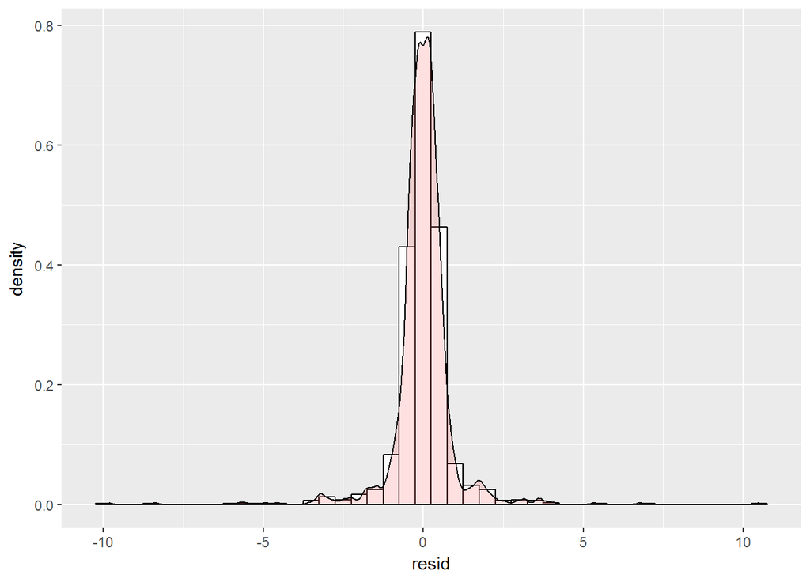

```r
library(ggplot2)
residuals <- data.frame(resid(MLexamp.8))
names(residuals) <- "resid"
ggplot(residuals, aes(x=resid)) +
    geom_histogram(aes(y=..density..),  binwidth=.5, colour="black", fill="white") +
    geom_density(alpha=.2, fill="#FF6666")
```

```r
summary(residuals)
```

```
##      resid
##  Min.   :-9.83553
##  1st Qu.:-0.32942
##  Median : 0.00561
##  Mean   : 0.00000
##  3rd Qu.: 0.33403
##  Max.   :10.47782
```

```r
#residuals
```

## Exercises

This exercise uses the `/data/prefdata.csv` dataset. it contains measurements of leaf mass per area (LMA), and distance from the top of the tree (dfromtop) on 35 trees of two species. We want to know whether LMA decreases with dfromtop as expected, and whether this decrease in LMA with distance from top differs by species.

1. read the data and inspect the first few rows, and the species variable.
2. fit a linear regresion model by species (ignoring individual-level variation)

```
lm1 <- lm(LMA ~ species + dfromtop + species:dfromtop , data = prefdata)
summary(lm1)
```

3. plot the linear predictions (hint load the library visreg and use the function `visreg(lm1, "dfromtop", by = "species", overlay =TRUE)`)
4. Look at the anova table for the fitted linear regression model from the example above to confirm that LMA does not significantly change with dfromtop.
5. To see whether the relationship betwee LMA and dfromtop potentially varies from tree to tree, fit a linear regression separately for each tree using the lmlist function in the `lme4` package and then plot the outcome.

```
library(lme4)
fit linear regression by tree

lmList1 <- lmList(LMA ~ dfromtop | ID , data = prefdata)

extract the coefs (intercepts and slopes) for each tree
```

6. To specify random effects with `lmer` we add it to the formula in the right-hand side. For example, a random intercept for an `ID` (that is, the intercept will vary randomly among `IDs` ) is coded as(1|ID). If we also allow the slope of the relationship to vary, we specify it as (`dfromtop|ID`) the slope and intercept of the relationship between `LMA` and `dfromtop` will vary randomly between tree `IDs`.
- Fit a random intercept model (`pref_m1`) only with species::dfromtop interaction
- Fit a random intercept and slope model (`pref_m2`)
- Use the `AIC` (Akaike Information criterion) to compare (`pref_m1`) and (`pref_m2`) and conclude that we don’t need a random slope.
- Conclude dat `LMA` indeed decreases with `dfromtop`

```
lm1 <- lm(LMA ~ species + dfromtop + species:dfromtop , data = prefdata)
summary(lm1)
```